# Self-Driving Car Engineer Nanodegree

## Project: Build a Traffic Sign Recognition Classifier

In this notebook, a template is provided for you to implement your functionality in stages which is required to successfully complete this project. If additional code is required that cannot be included in the notebook, be sure that the Python code is successfully imported and included in your submission, if necessary. Sections that begin with **'Implementation'** in the header indicate where you should begin your implementation for your project. Note that some sections of implementation are optional, and will be marked with **'Optional'** in the header.

In addition to implementing code, there will be questions that you must answer which relate to the project and your implementation. Each section where you will answer a question is preceded by a **'Question'** header. Carefully read each question and provide thorough answers in the following text boxes that begin with **'Answer:'**. Your project submission will be evaluated based on your answers to each of the questions and the implementation you provide.

> **Note:** Code and Markdown cells can be executed using the **Shift + Enter** keyboard shortcut. In addition, Markdown cells can be edited by typically double-clicking the cell to enter edit mode.

## Step 0: Load The Data

```python
#importing some useful packages
import tensorflow as tf
import matplotlib.pyplot as plt
import matplotlib.image as mpimg
import numpy as np
import cv2
import pickle
import pandas as pd
import random
import math
%matplotlib inline
print("Amazingly all libraries were loaded!!")
```

```
Amazingly all libraries were loaded!!
```

```python
# Load pickled data

# TODO: Fill this in based on where you saved the training and testing data
## Please change this to folder where you place the notebook

training_file = './Data/train.p'
testing_file = './Data/test.p'

try:
    #pickle.dump(train, training_file, protocol=2)
    with open(training_file, mode='rb') as f:
        train = pickle.load(f)
    with open(testing_file, mode='rb') as f:
        test = pickle.load(f)

    #We will keep the Original Images and Labels here
    X_train, y_train = train['features'], train['labels']
    X_test, y_test = test['features'], test['labels']

    print('Training and Test datasets loaded.')

except Exception as e:
    print('Loading datasets failure')
```

```
Training and Test datasets loaded.
```

## Step 1: Dataset Summary & Exploration

The pickled data is a dictionary with 4 key/value pairs:

- `'features'` is a 4D array containing raw pixel data of the traffic sign images, (num examples, width, height, channels).
- `'labels'` is a 1D array containing the label/class id of the traffic sign. The file `signnames.csv` contains id -> name mappings for each id.
- `'sizes'` is a list containing tuples, (width, height) representing the the original width and height the image.
- `'coords'` is a list containing tuples, (x1, y1, x2, y2) representing coordinates of a bounding box around the sign in the image. **THESE COORDINATES ASSUME THE ORIGINAL IMAGE. THE PICKLED DATA CONTAINS RESIZED VERSIONS (32 by 32) OF THESE IMAGES**

Complete the basic data summary below.

```python
### Replace each question mark with the appropriate value.

# Make sure the sizes of the images and thelabels agree
assert(len(X_train) == len(y_train))
assert(len(X_test) == len(y_test))


# TODO: Number of training examples
n_train = len(X_train)

# TODO: Number of testing examples.
n_test = len(X_test)

# TODO: What's the shape of an traffic sign image?
image_shape = X_train[0].shape

# TODO: How many unique classes/labels there are in the dataset.
n_classes = len(set(y_train))

print("Number of training examples =", n_train)
print("Number of testing examples =", n_test)
print("Image data shape =", image_shape)
print("Number of classes =", n_classes)
print('Shape Original:', X_train.shape)
```

```
Number of training examples = 39209
Number of testing examples = 12630
Image data shape = (32, 32, 3)
Number of classes = 43
Shape Original: (39209, 32, 32, 3)
```

Visualize the German Traffic Signs Dataset using the pickled file(s). This is open ended, suggestions include: plotting traffic sign images, plotting the count of each sign, etc.

The [Matplotlib](http://matplotlib.org/) [examples](http://matplotlib.org/examples/index.html) and [gallery](http://matplotlib.org/gallery.html) pages are a great resource for doing visualizations in Python.

**NOTE:** It's recommended you start with something simple first. If you wish to do more, come back to it after you've completed the rest of the sections.

```python
## Function that will Return the Sign Description by providing the index ( Index -> Description)
signNames = pd.read_csv('signnames.csv', sep=',')

def SignDescription(SignIdx):
    signName = signNames[signNames['ClassId']==SignIdx]['SignName'][SignIdx]
    #print (signName)
    return signName
```

```
 ******* Sample images *******
```

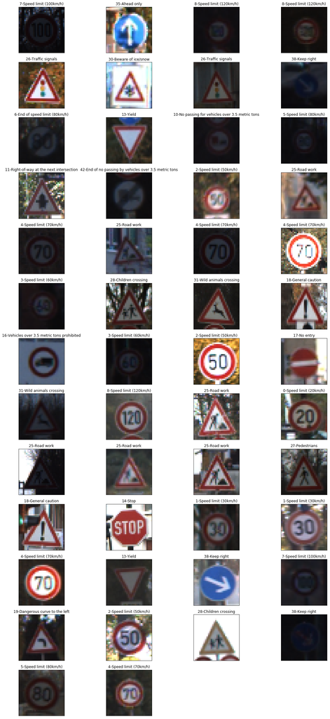

```python
### Data exploration visualization goes here.
### Feel free to use as many code cells as needed.


# Visualizations will be shown in the notebook.

# Plot four sample images
print(' ******* Sample images ******* ')
plt.figure(figsize=(20,50))
for i in range(50):
    index = random.randint(0, n_train)
    plt.subplot(15,4,i+1)

    plt.xticks([])
    plt.yticks([])
    plt.imshow(X_train[index])
    SignIdx = y_train[index]
    #print(str(SignIdx) + "-" + SignDescription(SignIdx))
    plt.title(str(SignIdx) + "-" + SignDescription(SignIdx))
    #plt.show()
```

### 1.1 Observations

As we can see above, the training images have different brightness, are at different angles, some are very blurred. The variety on the set it’s great to make sure our CNN gets trained and learns how to generilize and identify signals in a variety of optical conditions. It’s has been suggested to convert images into greyscale to, somehow, normalize all color rages and enhance the features that we want to detect and learn from. Also to normilize the brightness we will will use a methode called "Histogram equalization".

## Step 2: Design and Test a Model Architecture

Design and implement a deep learning model that learns to recognize traffic signs. Train and test your model on the [German Traffic Sign Dataset](http://benchmark.ini.rub.de/?section=gtsrb&subsection=dataset).

There are various aspects to consider when thinking about this problem:

- Neural network architecture
- Play around preprocessing techniques (normalization, rgb to grayscale, etc)
- Number of examples per label (some have more than others).
- Generate fake data.

Here is an example of a [published baseline model on this problem](http://yann.lecun.com/exdb/publis/pdf/sermanet-ijcnn-11.pdf). It's not required to be familiar with the approach used in the paper but, it's good practice to try to read papers like these.

**NOTE:** The LeNet-5 implementation shown in the classroom at the end of the CNN lesson is a solid starting point. You'll have to change the number of classes and possibly the preprocessing, but aside from that it's plug and play!

### Implementation

Use the code cell (or multiple code cells, if necessary) to implement the first step of your project. Once you have completed your implementation and are satisfied with the results, be sure to thoroughly answer the questions that follow.

### 1.2 Image Pre-processing

```python
def grayscale(img):
    return cv2.cvtColor(img, cv2.COLOR_BGR2GRAY)

def equalizeHist(img):
    img_shape = img.shape
    try:
        n_channels = img_shape[2]
        grayScale = False
    except:
        grayScale = True

    if grayScale:
        img = cv2.equalizeHist(img)
    else:
        for ch in range(0, n_channels-1):
            img[:,:,ch] = cv2.equalizeHist(img[:,:,ch])

    return img

def canny(img, low_threshold, high_threshold):
    """Applies the Canny transform"""
    return cv2.Canny(img, low_threshold, high_threshold)

def gaussian_blur(img, kernel_size):
    """Applies a Gaussian Noise kernel"""
    return cv2.GaussianBlur(img, (kernel_size, kernel_size), 0)
```

### Greyscale, Histogram equalization

#### 1) Greyscale to keep the range of color normilized

#### 2) Histogram equalization to keep the brightness of all images normalized (the very dark ones will become brighter and the very bright ones will get slighly darker)

```python
from numpy import newaxis

# convert to B/W
X_train_bw = np.array([grayscale(image) for image in X_train])
X_test_bw = np.array([grayscale(image) for image in X_test])
#X_train_bw = X_train
#X_test_bw = X_test
print('Shape after converting to grayscale:', X_train_bw[0].shape)

# apply histogram equalization
X_train_hst_eq = np.array([equalizeHist(image) for image in X_train_bw])
X_test_hst_eq = np.array([equalizeHist(image) for image in X_test_bw])
print('Shape after Histogram Equalization:', X_train_hst_eq.shape)
```

```
Shape after converting to grayscale: (32, 32)
Shape after Histogram Equalization: (39209, 32, 32)
```

### Mean substration and Normalization

```python
### Preprocess the data here.
# 1) MEAN SUBTRACTION
def meanSubtraction(image_data):
    return image_data - np.mean(image_data, axis = 0)

X_train_meanSub = meanSubtraction(X_train_hst_eq)
X_test_meanSub = meanSubtraction(X_test_hst_eq)
print('Mean Subtraction performed succesfully')
print('Shape after Mean Subtraction :', X_train_meanSub.shape)

# 2) NORMALIZATION
# I found 2 ways to normilze that I want to check how different these 2 techniques are.



def normalize1(image_data):
    a = -0.5
    b = 0.5
    grayscale_min = 0
    grayscale_max = 255
    return a + ( ( (image_data - grayscale_min)*(b - a) )/( grayscale_max - grayscale_min ) )

X_train_norm1 = normalize1(X_train_meanSub)
X_test_norm1 = normalize1(X_test_meanSub)
print('Shape after Normalization 1 :', X_train_norm1.shape)

def normalize2(image_data):
    return (image_data - image_data.mean()) / (np.max(image_data) - np.min(image_data))

X_train_norm2 = normalize2(X_train_hst_eq)
X_test_norm2 = normalize2(X_test_hst_eq)
print('Shape after Normalization 2 :', X_train_norm2.shape)

#assert np.array_equal(X_train_norm1, X_train_norm2), 'Normalization techniques 1 and 2 are not producing equal images.'


def imageStd(image_data):
    return tf.image.per_image_standardization(image_data)

#X_train_std = np.array([imageStd(image) for image in X_train])
#X_test_std = np.array([grayscale(image) for image in X_test])
#X_train_bw = X_train
#X_test_bw = X_test
#print('Shape after Standarization:', X_train_std[0].shape)

# 3) PCA/Whitening is good for completeness, but these transformations are not used with Convolutional Networks in praactice.

### Feel free to use as many code cells as needed.
```

```
Mean Subtraction performed succesfully
Shape after Mean Subtraction : (39209, 32, 32)
Shape after Normalization 1 : (39209, 32, 32)
Shape after Normalization 2 : (39209, 32, 32)
```

#### Reshape to make sure the images are pefectly ready (have a shape of 32x32x1) for the Convolution layer Input

```python
### Finally we will reshape
# We will do it for only the Normalized set that we decide to use; either Normilize 1 or 2
# reshape for conv layer

X_train_reshaped = X_train_norm2[..., newaxis]
X_test_reshaped = X_test_norm2[..., newaxis]

#X_train_reshaped = X_train_norm1
#X_test_reshaped = X_test_norm1
print('Shape after reshape:', X_train_reshaped.shape)
```

```
Shape after reshape: (39209, 32, 32, 1)
```

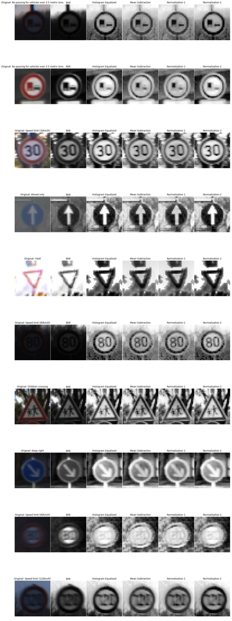

```python
# This is to Compare a randomly selected image from the training set with all the pre-processed results step by step
# to visualy inspect the diferences.

# show image of N random data points
count = 10
fig, axs = plt.subplots(count, 6, figsize=(count*2, count*6))
fig.subplots_adjust(hspace = .2, wspace=.01)
axs = axs.ravel()
for i in range(0, count*6, 6):
    index = random.randint(0, n_train)

    axs[i].axis('off')
    axs[i].imshow(X_train[index]) # ORIGINAL
    axs[i].set_title("Original- " + SignDescription(y_train[index]))

    axs[i+1].axis('off')
    axs[i+1].imshow(X_train_bw[index], cmap='gray')
    axs[i+1].set_title("B/W")

    axs[i+2].axis('off')
    axs[i+2].imshow(X_train_hst_eq[index], cmap='gray')
    axs[i+2].set_title("Histogram Equalized")

    axs[i+3].axis('off')
    axs[i+3].imshow(X_train_meanSub[index], cmap='gray')
    axs[i+3].set_title("Mean Subtraction")

    axs[i+4].axis('off')
    axs[i+4].imshow(X_train_norm1[index], cmap='gray')
    axs[i+4].set_title("Normalization 1")

    axs[i+5].axis('off')
    axs[i+5].imshow(X_train_norm2[index], cmap='gray')
    axs[i+5].set_title("Normalization 2")
```

### Question 1

*Describe how you preprocessed the data. Why did you choose that technique?*

**Answer:** Before I answer this question I’d like to elaborate the 2 different steps we use to pre-process the data before we feed it into the CNN and how these steps affect significantly the answer.

1. The first step is to manipulate the raw data simply because we want it to be within an acceptable range and format for the network. Transformation and normalization are two widely used preprocessing methods to achieve this objective. Transformation involves manipulating raw data inputs to create a single input to a net (many to one), while normalization is a manipulation performed on a single data input to distribute the data evenly and scale it into an acceptable range for the network (one to one). Knowledge of the domain is important in choosing preprocessing methods to highlight underlying features in the data, which can increase the network's ability to learn the association between inputs and outputs. There are many different types of manipulations depending on the field and type of data we are using. Some simple preprocessing methods include computing differences between or taking ratios of inputs. In financial forecasting transformations might involve the use of standard technical indicators. Also moving averages, for example, which are utilized to help smooth price data. Other methods for data normalization that I found out there are min-max normalization (which is what I used here), z-score normalization and normalization by decimal scaling. As can see below, I used 2 different Normalization techniques and I plotted a random image and its normalized 2 versions and decided to train the CNN with both to see if there is any significant change in accuracy and performance. After 2 runs on each I decided to stick with Normalization 2.
2. The second step after the data is ready for the net, is to shuffle the training data. But why? Well, the learning in a neural network follows a walk that minimizes the error which depends on the current example. Some walks will end at a local minimum while we are seeking a global one. Therefore if we always start the training at the same sample point we could end up stuck in that local minima over and over again and that’s why it is extremely important to shuffle the training data. I did want to mention an interesting line of research from Bengio et al. on something they call “curriculum learning”. Here’s a sentence from the opening paragraph: “By choosing which examples to present and in which order to present them to the learning system, one can guide training and remarkably increase the speed at which learning can occur.” On the same topic, I have read comments from people like Viresh Ranjan, PhD Student in Machine Learning where he states that theory and practice are totally different. Here’s what he said: “different random shuffling of the training set may lead to different parameters. In practice, doesn't make that much of a difference. Since the neural network objective functions are non-convex, using different ordering of training samples would lead to possibly different local minimas. However, in practice, we observe that using different ordering of training samples doesn't result in any drastic changes in performance.“ So going back to the question, after looking at the raw images we noticed that they are all 32x32x3. So we don't need to re-shape them and guarantee they have this size. Why 32x32x3...Well, we look for a minimal factor where images don’t lose any information and we convey to a 32x32x3. I WILL NOT SHUFFLE HERE UNTIL THE TRAINING DATA IS SPLIT INTO 2 DATASETS: FINAL TRAINING SET AND VALIDATION SET ### Added after submission following suggestions: Look above

```python
# Plot a histogram of the count of the number of examples of each sign
# in the trainig set
def PlotHistogram(data):
    fig, ax = plt.subplots()

    n_examples_per_sign, bins, patches = ax.hist(data, bins=n_classes, normed = False, histtype='bar', orientation='horizontal')

    print("The sing with the highest number of exampels is:", SignDescription(np.argmax(n_examples_per_sign)))
    print ("With = {:.0f}".format(np.max(n_examples_per_sign)) + " examples")

    # _____ This IS JUST TO COLOR THE HISTOGRAM
    bin_centers = 0.5 * (bins[:-1] + bins[1:])

    # scale values to interval [0,1]
    col = bin_centers - min(bin_centers)
    col /= max(col)

    # This is  the colormap I'd like to use.
    cm = plt.cm.get_cmap('RdYlBu_r')

    for c, p in zip(col, patches):
        plt.setp(p, 'facecolor', cm(c))
    # ________________________________________

    plt.title('Number of images of each sign in the training set')
    plt.ylabel('Sign')
    plt.xlabel('Count')
    ax.set_yticks(signNames['ClassId'])
    ax.set_yticklabels(signNames['SignName'], rotation=0 )
    for tick in ax.yaxis.get_major_ticks():
        tick.label.set_fontsize(6)

    # Plot histogram.
    plt.plot()

    return n_examples_per_sign
```

```
The sing with the highest number of exampels is: Speed limit (50km/h)
With = 2250 examples
```

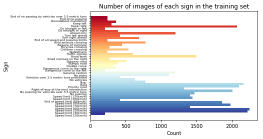

```python
n_examples_per_sign = PlotHistogram(y_train)
```

```python
## After researching on what and why transformations we can do over the images to "generate" new ones, I came accross KERAS
# Image Generator that points at these set:
#      1) rotation,
#      2) width shift,
#      3) height shift,
#      4) shear,
#      5) zoom,
#      6) horizontal flip,
# Obviously I don't have time to develop these but I'll give it a try by "shifting and Rotating" using
# scipy.ndimage.interpolation.shift and .rotate
import scipy.ndimage
def TransformImg(image):
    if (random.choice([True, False])):
        Newimage = scipy.ndimage.interpolation.shift(image, [random.randrange(-2, 2), random.randrange(-2, 2), 0])
    else:
        Newimage = scipy.ndimage.interpolation.rotate(image, random.randrange(-180, 180), reshape=False)
    return Newimage

# I found an amazing help at:
# https://www.tensorflow.org/api_docs/python/image/flipping_rotating_and_transposing

def TransformImg2(image):
    Transformation = np.random.choice(5) #  Only from 0 to 4 because there is a bug on tf.Rot90!!
    #print (Transformation)
    Trans_img = image
    if Transformation == 0:
        Trans_img = tf.image.flip_up_down(image)
        #print(Transformation)
    else:
        if Transformation == 1:
            Trans_img = tf.image.random_flip_up_down(image, seed=None)
            #print(Transformation)
        else:
            if Transformation == 2:
                Trans_img = tf.image.flip_left_right(image)
                #print(Transformation)
            else:
                if Transformation == 3:
                    Trans_img = tf.image.random_flip_left_right(image, seed=None)
                    #print(Transformation)
                else:
                    if Transformation == 4:
                        Trans_img = tf.image.transpose_image(image)
                        #print(Transformation)
                    else:
                        if Transformation == 5:
                            rot90 = random.randint(1, 3)
                            Trans_img = tf.image.rot90(image, k=rot90, name=None)
                            print(rot90)
    print(Trans_img.get_shape().as_list())
    return Trans_img
```

```
Generated: 200
The sign being trasformed: Speed limit (50km/h)
```

[figure not shown]

```python
# Before I actually generate all the images I believe we will need to improve our training, I
# need to test this "TransformImg" function and also test the iterative technique I want to use.
# In this technique I want to start with the original image, since there I can't apply the trasforamtions
# to the images gray and Hist Equalized.
# In the next iteration I will use the already transformed image to generate the sencod one...and so on and so forth
# until I generate enough of them. There are plenty of advantages and disadvantages of doind so
# but I really need to keep it simple. THIS APPROACH DID NOT WORK. Despite the fact that we will
# generate many equal images, I will always have to use the original and randomly transform it using
# the new ""TransformImg2" that randomly will apply one of the 6 possible trnaformations

# It's also important to note that I'll start with the original 32x32 COLOR image and not the
# pre-processed ones
index = random.randint(0, n_train)
Original = X_train[index]
Needed_Images = 200
Added_Images = 0
generated_images = []
while Added_Images < Needed_Images:
    image = TransformImg(Original)
    Added_Images = Added_Images + 1
    generated_images.append(image)
print("Generated:", Added_Images)

# Let's now plot, let's say, 10 random of the generated images. BUT we need to plot the original and
# the last one to see if this iterative process degenerates the images or if it's valid
# show image of N random data points
count = 10+2
fig, axs = plt.subplots(3, 4)# figsize=(count*2, count*4))
fig.subplots_adjust(hspace = .5, wspace=.1)
axs = axs.ravel()

print("The sign being trasformed:", SignDescription(y_train[index]))

# Original
axs[0].axis('off')
axs[0].imshow(X_train[index]) # ORIGINAL
axs[0].set_title("Original")

for i in range(1, count-1):
    index = random.randint(0, Added_Images)

    axs[i].axis('off')
    axs[i].imshow(generated_images[index])
    axs[i].set_title(str(i))

axs[11].axis('off')
axs[11].imshow(generated_images[Added_Images-1])
axs[11].set_title(str(Added_Images))
```

```python
### Generate additional data (OPTIONAL!)
# When looking at the histogram above, we notice that, naturally, the CNN would be trained with more examples of some type of
# signals than other with significantly less examples and therefore be more prone to identify those. For this reason it would be
# ideal to augment/generate training images to, somehow, try to equalize the amount of exampels per sign.
# (Look at Question 2 below for details)

generated_images = []
generated_labels = []
generated_per_class = []

for class_index in range(n_classes):
    generated_per_class.append(0)
    class_example_count = n_examples_per_sign[class_index]
    add_examples = np.max(n_examples_per_sign) - class_example_count
    print("Sign {:.0f} has only {:.0f} examples, we want to create {:.0f} more.".format(class_index, class_example_count, add_examples))
    # We will generate images based on the already gray and normilized ones. I will start with the original and then use the
    # new generated ones as source to produce the next one. This way I will minimaze generating the same images.
    for Image2Transform, Image2Transform_Label in zip(X_train, y_train):
        if class_index == Image2Transform_Label:
            Original = Image2Transform
            while generated_per_class[class_index] < (int(add_examples)):
                image = TransformImg(Original)
                generated_per_class[class_index] = generated_per_class[class_index] + 1
                generated_images.append(image)
                generated_labels.append(class_index)
    print("Generated:", generated_per_class[class_index])
```

```
Sign 0 has only 210 examples, we want to create 2040 more.
Generated: 2040
Sign 1 has only 2220 examples, we want to create 30 more.
Generated: 30
Sign 2 has only 2250 examples, we want to create 0 more.
Generated: 0
Sign 3 has only 1410 examples, we want to create 840 more.
Generated: 840
Sign 4 has only 1980 examples, we want to create 270 more.
Generated: 270
Sign 5 has only 1860 examples, we want to create 390 more.
Generated: 390
Sign 6 has only 420 examples, we want to create 1830 more.
Generated: 1830
Sign 7 has only 1440 examples, we want to create 810 more.
Generated: 810
Sign 8 has only 1410 examples, we want to create 840 more.
Generated: 840
Sign 9 has only 1470 examples, we want to create 780 more.
Generated: 780
Sign 10 has only 2010 examples, we want to create 240 more.
Generated: 240
Sign 11 has only 1320 examples, we want to create 930 more.
Generated: 930
Sign 12 has only 2100 examples, we want to create 150 more.
Generated: 150
Sign 13 has only 2160 examples, we want to create 90 more.
Generated: 90
Sign 14 has only 780 examples, we want to create 1470 more.
Generated: 1470
Sign 15 has only 630 examples, we want to create 1620 more.
Generated: 1620
Sign 16 has only 420 examples, we want to create 1830 more.
Generated: 1830
Sign 17 has only 1110 examples, we want to create 1140 more.
Generated: 1140
Sign 18 has only 1200 examples, we want to create 1050 more.
Generated: 1050
Sign 19 has only 210 examples, we want to create 2040 more.
Generated: 2040
```

[output cut: 31 more lines]

```
Generated: 1050
Sign 36 has only 390 examples, we want to create 1860 more.
Generated: 1860
Sign 37 has only 210 examples, we want to create 2040 more.
Generated: 2040
Sign 38 has only 2070 examples, we want to create 180 more.
Generated: 180
Sign 39 has only 300 examples, we want to create 1950 more.
Generated: 1950
Sign 40 has only 360 examples, we want to create 1890 more.
Generated: 1890
Sign 41 has only 240 examples, we want to create 2010 more.
Generated: 2010
Sign 42 has only 240 examples, we want to create 2010 more.
Generated: 2010
```

```python
# All this images generated should be pre-processed like we did before: grayscale, etc..
# convert to B/W
generated_images = np.array([grayscale(image) for image in generated_images])
# equalizeHist
generated_images = np.array([equalizeHist(image) for image in generated_images])
# meanSubtraction
generated_images = meanSubtraction(generated_images)
# Normilize 2
generated_images = normalize2(generated_images)
# Reshape
generated_images = generated_images[..., newaxis]

# Add the generated data to original data
X_train_augmented = np.append(np.array(X_train_reshaped), np.array(generated_images), axis=0)
y_train_augmented = np.append(np.array(y_train), np.array(generated_labels), axis=0)

### and split the data into training/validation/testing sets here.
 # Splitting below
### Feel free to use as many code cells as needed.
```

```
The sing with the highest number of exampels is: Speed limit (20km/h)
With = 2250 examples
```

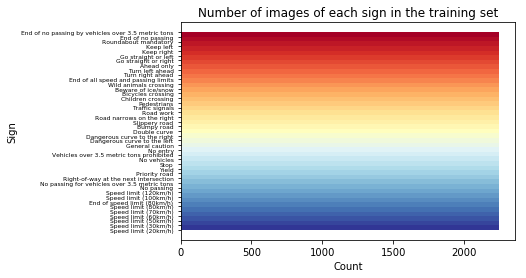

```python
n_examples_per_sign = PlotHistogram(y_train_augmented)
```

```python
#________________________________________
#         SPLITTING THE DATA
#________________________________________
# We will split the Original Training set into a final Training set and a Validation test.

from sklearn.utils import shuffle

def data_split(Input_images, Output_labels, train_percent=.8):
    m = len(Input_images)
    train_end = int(train_percent * m)

    #Shuffle before we slpit
    Input_images, Output_labels = shuffle(Input_images, Output_labels, random_state=42)

    X_train = Input_images[:train_end]
    y_train = Output_labels[:train_end]

    X_validation = Input_images[train_end:]
    y_validation = Output_labels[train_end:]

    return X_train, y_train, X_validation, y_validation
```

```python
# Here is where we actually split the data

train_percent = 0.8 # 80% will be final training data and 20% will used as a validation data
X_train_final, y_train_final, X_validation, y_validation = data_split(X_train_augmented, y_train_augmented, train_percent)

n_train_final = len(X_train_final)
n_validation = len(X_validation)

print("Number of Final training examples =", n_train_final)
print("% training examples =", n_train_final/len(X_train_augmented)*100)
print("Number of Validation examples =", n_validation)

image_shape = X_train_final[347].shape
print("The new image shape is:",image_shape)
```

```
Number of Final training examples = 77400
% training examples = 80.0
Number of Validation examples = 19350
The new image shape is: (32, 32, 1)
```

### Question 2

*Describe how you set up the training, validation and testing data for your model. **Optional**: If you generated additional data, how did you generate the data? Why did you generate the data? What are the differences in the new dataset (with generated data) from the original dataset?*

**Answer:** Just after a quick research I realized that deciding the percentages of the full raw data set that can be used to setup the training, validation and testing sets it's a complex and controverted topic. Doesn't look like there is a strict method to follow or specific percentages to use. The other interesting thing I learnt was that splitting without resampling (cross-validation, or better: bootstrapping) is unreliable unless you have an enormous sample (e.g., N>20000N>20000). Rigorous internal validation using the bootstrap is usually preferred, assuming that you program all model selection steps so they can be repeated in each bootstrap loop. And one of the problems with split sample approaches, besides volatility, is the difficulty in choosing the split fractions. After considerable reading I decided to keep 80% for Training and 20% for validation while I'll leave the Testing set untouched.Look like this is a good starting point that I will change later to study any changes in performance and accuracy.

```python
### Define your architecture here.
### Feel free to use as many code cells as needed.
```